# LIMS RQ-PCR Data Analysis

Michaela Kotrová

m.kotrova@med2.uni-kiel.de

Last updated: 2025-05-08 11:00

**Imported Files:**

- Primertests: `primer_aufbereitet_20250311.xlsx`
- Follow-ups: `RQ_gesamt_20250311.xlsx`

## Updates

- Capped all CT values at 45
- Excluded sample CT values < 15
- Excluded BC CT values < 20
- Added potential toDOs for Enrique
  - toDO-1
  - toDO-2
  - toDO-3
  - toDO-4
  - toDO-5
- Introduced IG/TR Rearrangement classes and applied them in the following plots instead of target genes:
  - Sample CT
  - BC CT
  - Primer counts
  - ΔCT ~ Rclass
  - ΔCT ~ t. gene + ann. temp.
  - Primer acceptance - absolute counts
  - Primer acceptance - percentages
  - Lebens BC
  - Assay sensitivity
  - Assay specificity
  - Sample CT values vs. MRD
- Improved visualisation of Sample CT values vs. MRD and computed the trend curve only for samples with MRD >=1e-04
- Added comparison of MRD in triplets (BM-BMtrephine-PB)
- Performed BM vs PB MRD analysis separately for samples on Blinatumomab
- Performed BM vs PB MRD analysis separately for samples after SCT
- In Assay characteristics each assay is now included only once, using the most recent values
- The trend curve in MRD by different target computed only for samples with both MRD values positive quantifiable

# 1 Primertests

## 1.1 Target genes

| Target gene | Freq |
| --- | --- |
| IGH | 10574 |
| TRG | 4385 |
| TRD | 4146 |
| IGK | 3312 |
| TRB | 2965 |
| IGL | 468 |
| BCL1 | 159 |
| MBR1 | 118 |
| TRA | 82 |
| AFF1:KMT2A | 79 |

[output cut: 39 more lines]

## 1.2 IG / TR Rearrangement clases

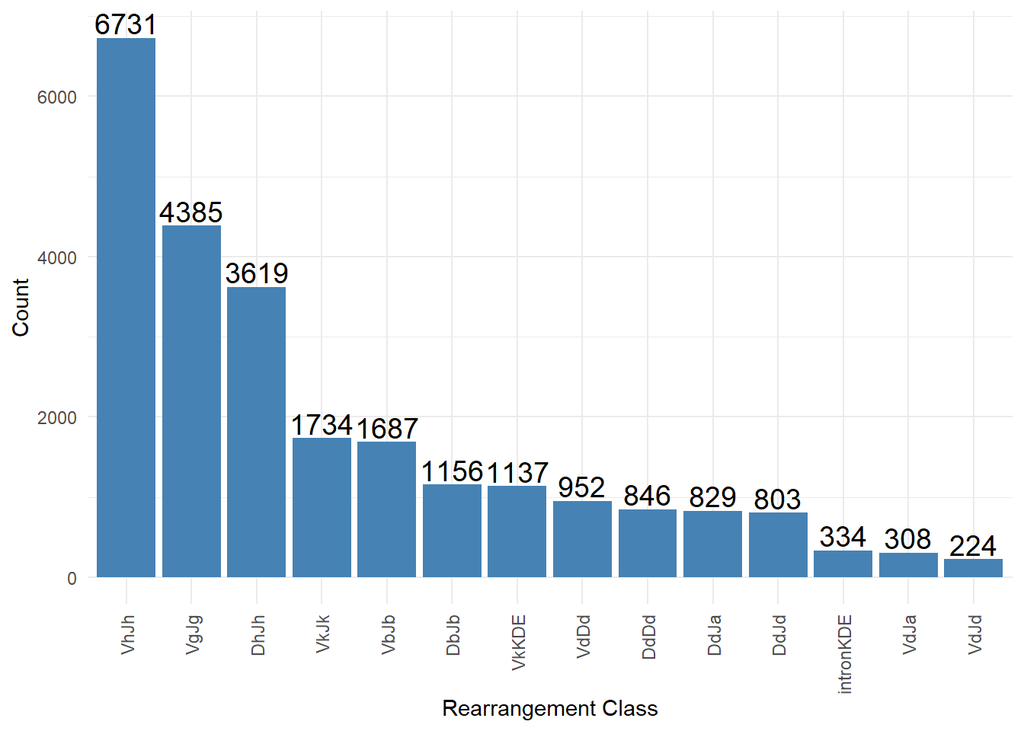

## 1.3 CT values

### 1.3.1 Sample CT

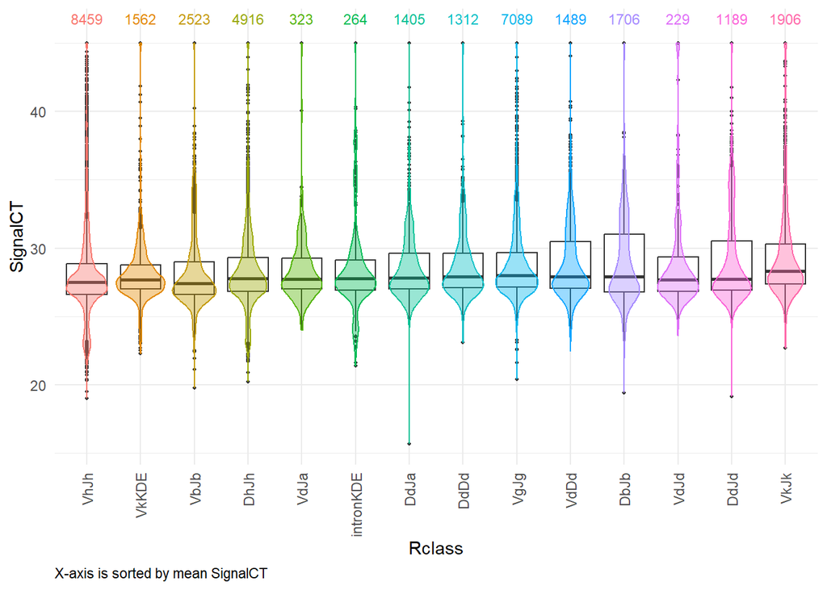

toDO-1: Sample CTs <15 or >50 and those with no numeric values skipped for now.  
Please correct these values in *primer_aufbereitet_20250311.xlsx*.  
(columns: *SignalCT_01*, *SignalCT_02*, *SignalCT_03*, *SignalCT_04*)

### 1.3.2 BC CT

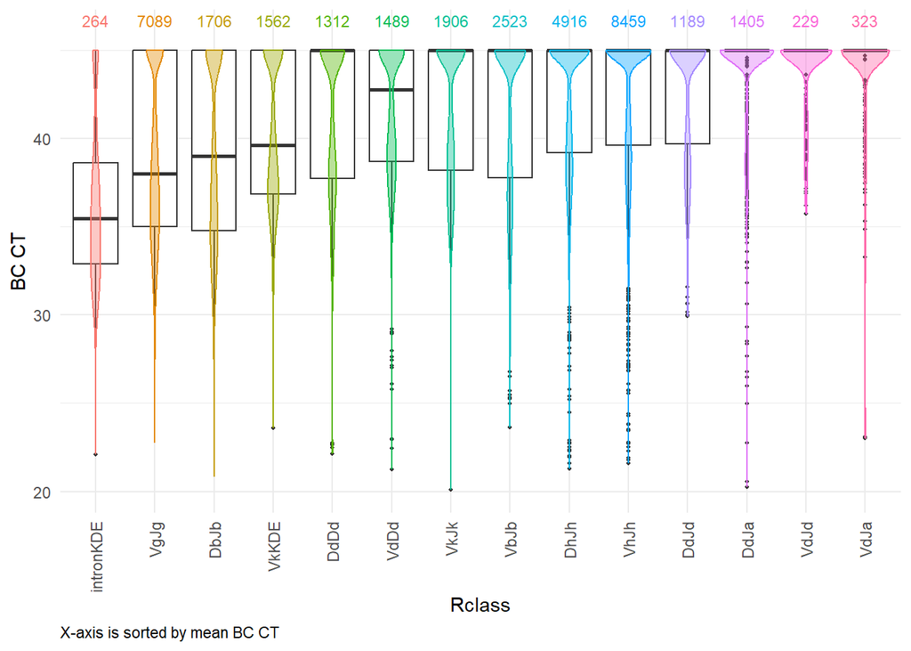

toDO-2: BC CTs <20 or >50 and those with no numeric values skipped for now.  
Please correct these values in *primer_aufbereitet_20250311.xlsx*.  
(columns: *BC_01*, *BC_02*, *BC_03*, *BC_04*)

## 1.4 Primer counts

| Rclass | 59 | 61 | 62 | 63 | 64 | 66 | Row_Sum |
| --- | --- | --- | --- | --- | --- | --- | --- |
| VdJd | 0 | 1 | 104 | 8 | 112 | 4 | 229 |
| intronKDE | 0 | 0 | 124 | 9 | 125 | 6 | 264 |
| VdJa | 0 | 2 | 151 | 9 | 158 | 3 | 323 |
| DdJd | 0 | 3 | 580 | 9 | 596 | 1 | 1189 |
| DdDd | 0 | 2 | 626 | 22 | 654 | 8 | 1312 |
| DdJa | 0 | 1 | 683 | 4 | 717 | 0 | 1405 |
| VdDd | 0 | 7 | 706 | 38 | 723 | 15 | 1489 |
| VkKDE | 0 | 3 | 743 | 34 | 766 | 16 | 1562 |
| DbJb | 0 | 5 | 783 | 53 | 836 | 29 | 1706 |
| VkJk | 0 | 2 | 910 | 38 | 951 | 5 | 1906 |
| VbJb | 0 | 3 | 1185 | 62 | 1238 | 35 | 2523 |
| DhJh | 0 | 8 | 2342 | 143 | 2369 | 54 | 4916 |
| VgJg | 0 | 9 | 3411 | 108 | 3560 | 1 | 7089 |
| VhJh | 2 | 12 | 4361 | 113 | 3928 | 43 | 8459 |
| Column_Sum | 2 | 58 | 16709 | 650 | 16733 | 220 | 34372 |

## 1.5 Signal/noise difference

### 1.5.1 ΔCT ~ Rclass

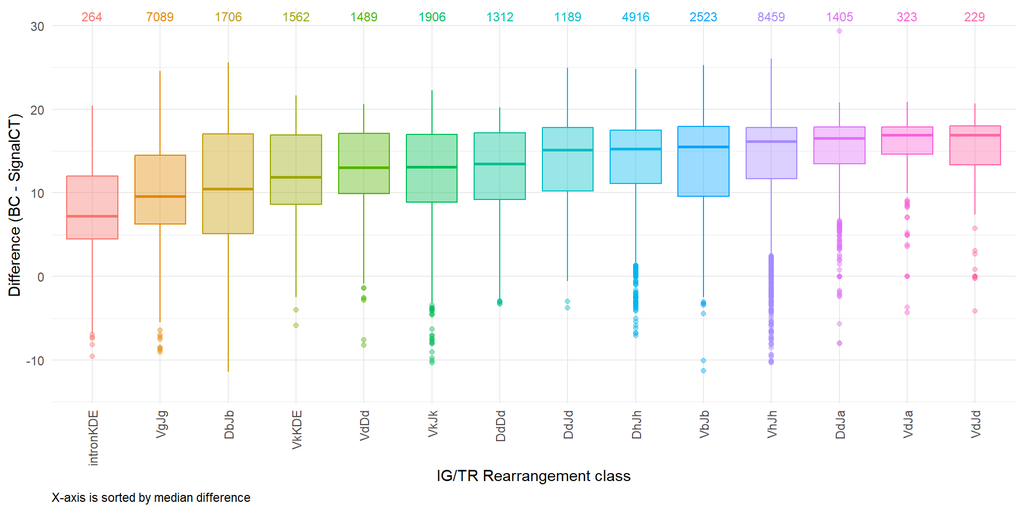

### 1.5.2 ΔCT ~ annealing temperature

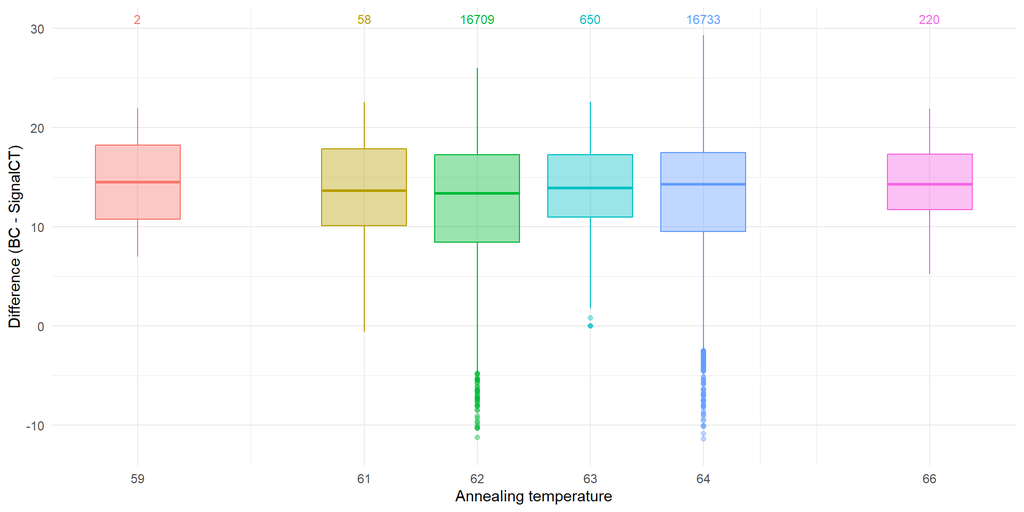

### 1.5.3 ΔCT ~ t. gene + ann. temp.

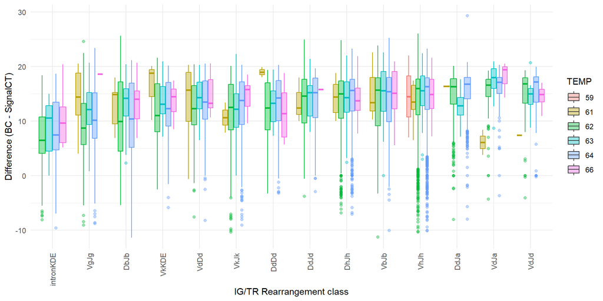

### 1.5.4 ΔCT 64°C - 62°C

#### 1.5.4.1 barplot

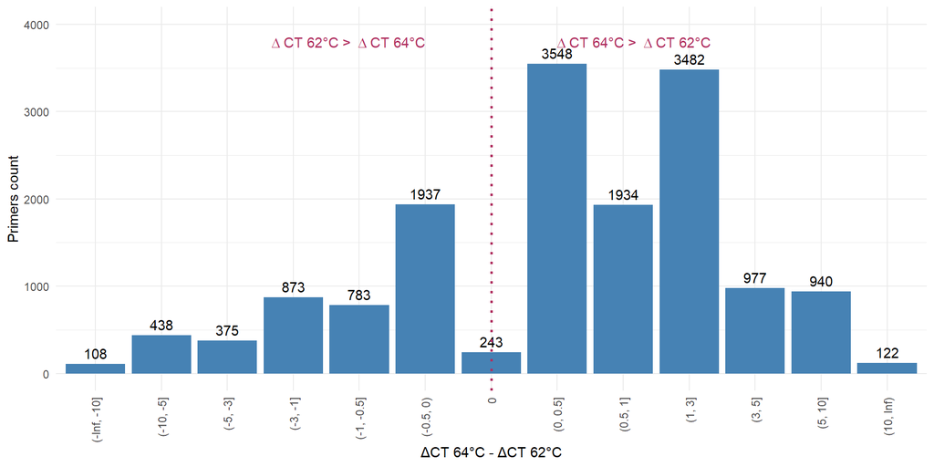

#### 1.5.4.2 Scatter plot

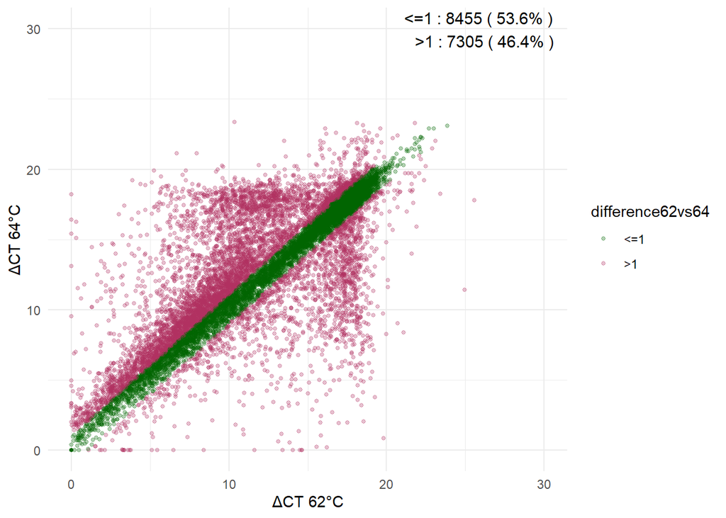

### 1.5.5 ΔRN

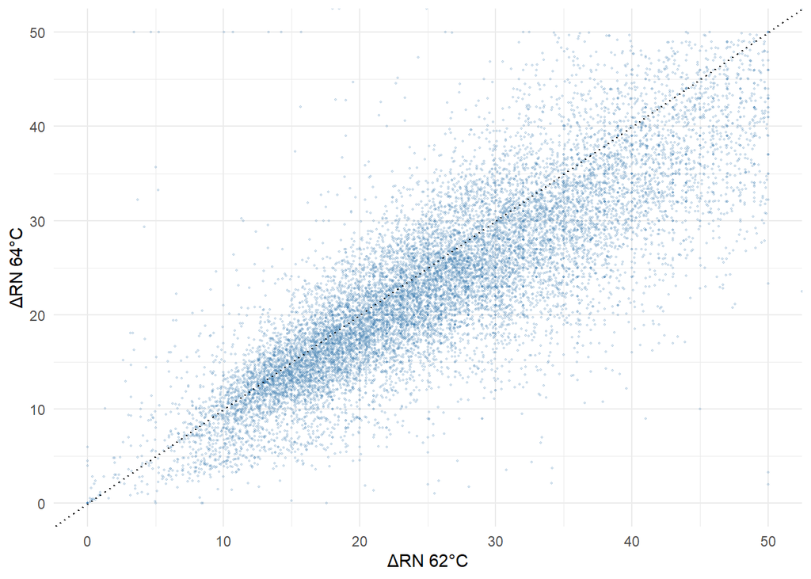

## 1.6 Primer acceptance

### 1.6.1 By rearrangement class

#### 1.6.1.1 Absolute numbers

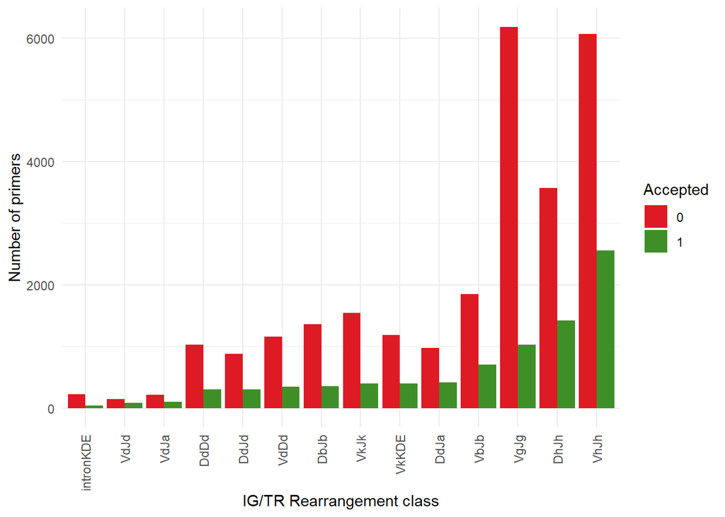

#### 1.6.1.2 Percentages

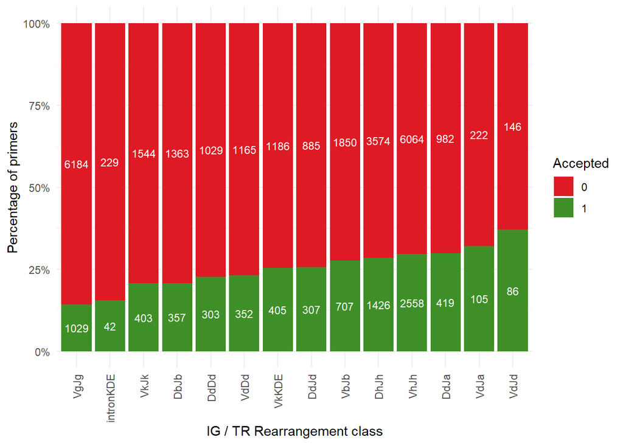

### 1.6.2 By annealing temperature

#### 1.6.2.1 Absolute numbers

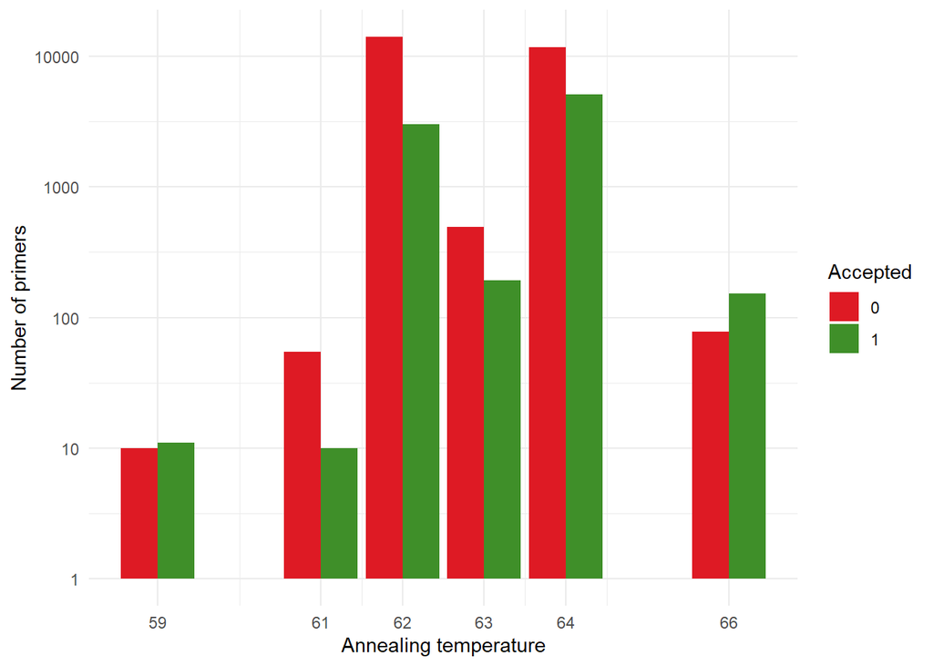

#### 1.6.2.2 Percentages

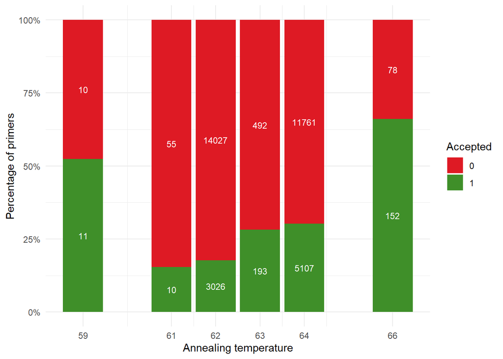

# 2 Follow-ups

## 2.1 Assay characteristics~Rclass

> Only assays with an available *Rclass* are included. In cases with multiple time-points, only the most recent value for each assay was retained.

### 2.1.1 Lebens BC

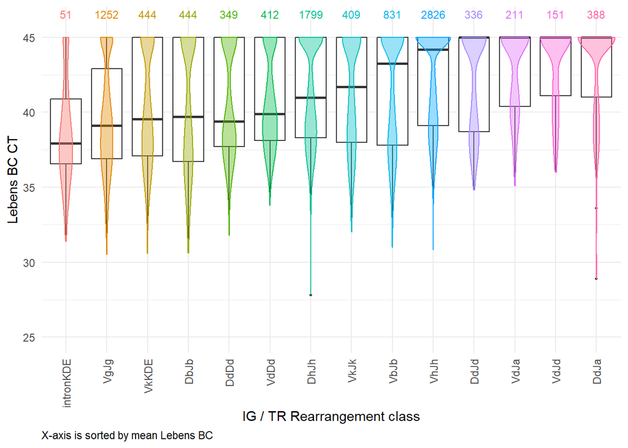

toDO-3: BC CTs <20 or >50 and those with no numeric values skipped for now.  
Please correct these values in the *RQ_gesamt_20250311.xlsx*.  
(column: *lebens_BC*)

### 2.1.2 Sensitivity

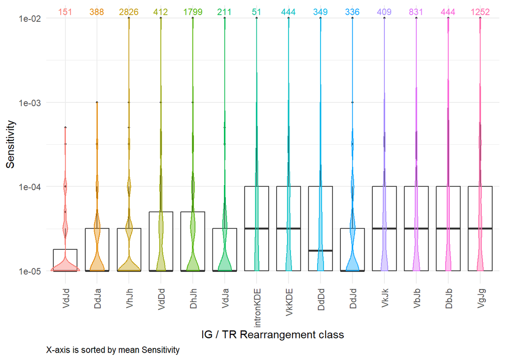

### 2.1.3 Specifity

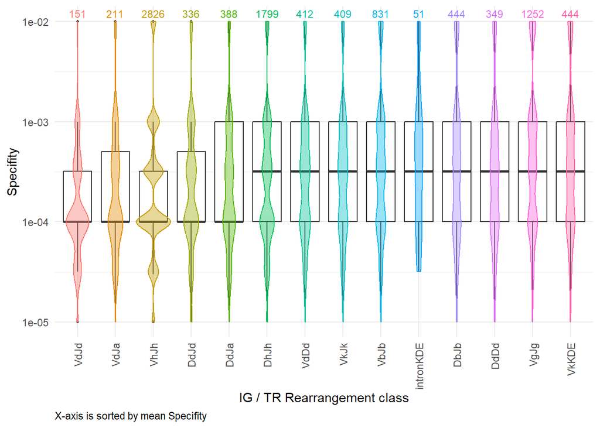

## 2.2 BM vs. PB MRD

> BM and PB samples collected <= 7 days apart. All assays per patient and date kept.

### 2.2.1 B-ALL

#### 2.2.1.1 All time-points

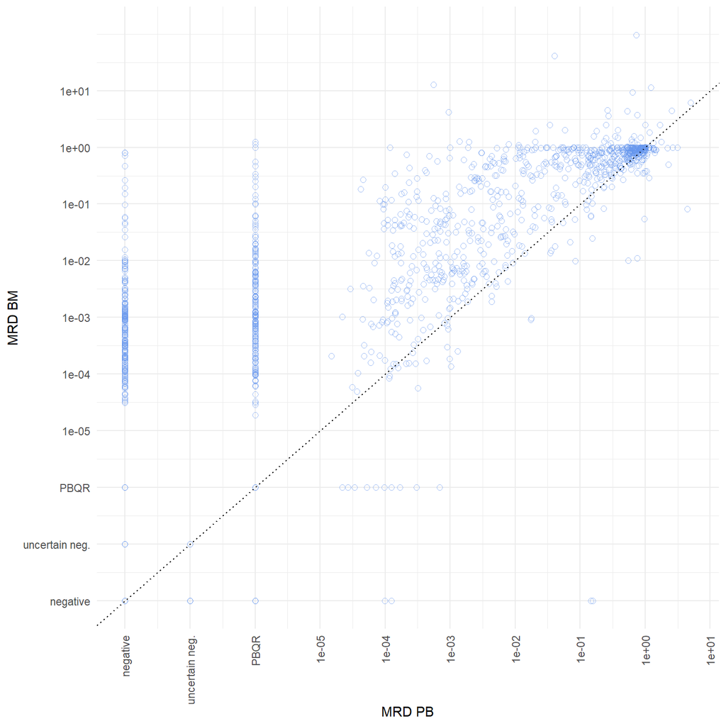

| BM_MRD | PB_MRD | count | pct |
| --- | --- | --- | --- |
| negative | negative | 4703 | 72.3 |
| positive | positive | 874 | 13.4 |
| PBQR | negative | 315 | 4.8 |
| positive | negative | 207 | 3.2 |
| positive | PBQR | 188 | 2.9 |
| PBQR | PBQR | 128 | 2 |
| negative | PBQR | 32 | 0.5 |
| uncertain negative | negative | 23 | 0.4 |
| negative | uncertain negative | 16 | 0.2 |
| PBQR | positive | 10 | 0.2 |

[output cut: 6 more lines]

#### 2.2.1.2 Samples on Blinatumomab

> All datapoints from the “All time-points” plot that have “blin” in the columns *visit* or *zeitp*.

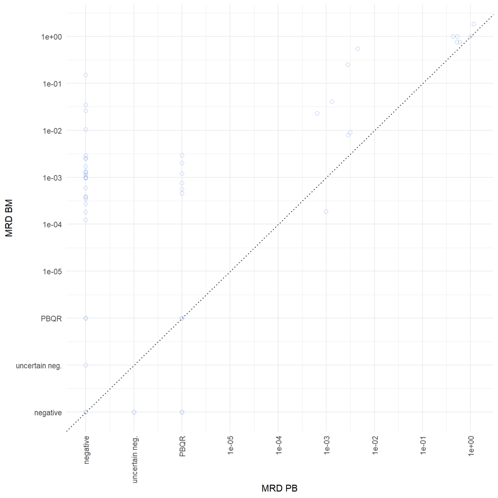

| BM_MRD | PB_MRD | count | pct |
| --- | --- | --- | --- |
| negative | negative | 232 | 78.6 |
| positive | negative | 22 | 7.5 |
| positive | positive | 13 | 4.4 |
| PBQR | PBQR | 12 | 4.1 |
| positive | PBQR | 6 | 2 |
| PBQR | negative | 4 | 1.4 |
| negative | PBQR | 3 | 1 |
| negative | uncertain negative | 2 | 0.7 |
| uncertain negative | negative | 1 | 0.3 |
| uncertain negative | PBQR | 0 | 0 |

[output cut: 6 more lines]

#### 2.2.1.3 Samples after stem cell transplantation

> All datapoints from the “All time-points” plot that have “sct”/“szt”/“allo”/“tx”, but not “vor” in the columns *visit* or *zeitp*.

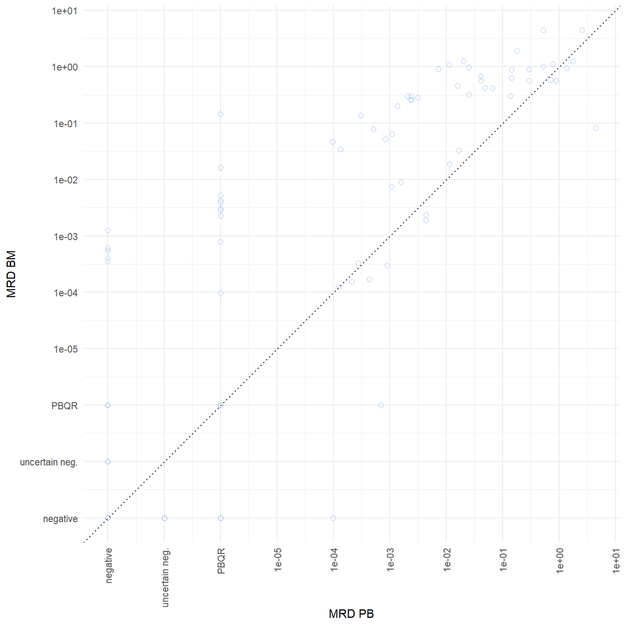

| BM_MRD | PB_MRD | count | pct |
| --- | --- | --- | --- |
| negative | negative | 744 | 86.9 |
| positive | positive | 48 | 5.6 |
| PBQR | negative | 27 | 3.2 |
| positive | PBQR | 10 | 1.2 |
| PBQR | PBQR | 6 | 0.7 |
| positive | negative | 5 | 0.6 |
| uncertain negative | negative | 5 | 0.6 |
| negative | uncertain negative | 5 | 0.6 |
| negative | PBQR | 4 | 0.5 |
| negative | positive | 1 | 0.1 |

[output cut: 6 more lines]

### 2.2.2 T-ALL

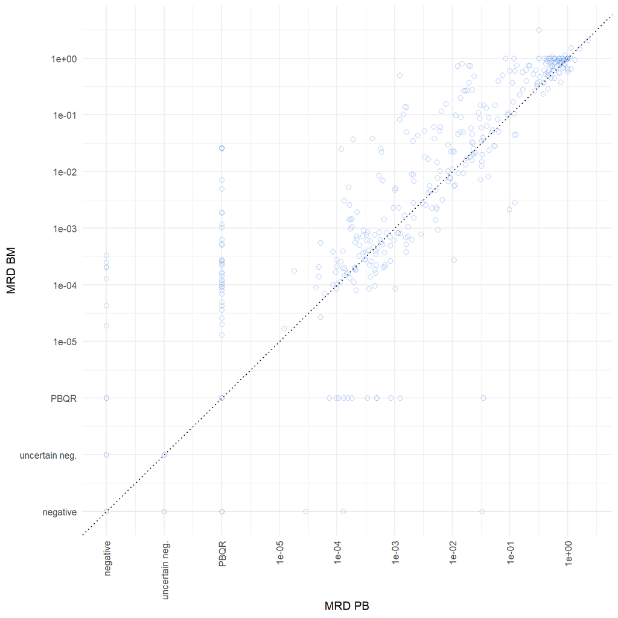

| BM_MRD | PB_MRD | count | pct |
| --- | --- | --- | --- |
| negative | negative | 1435 | 72 |
| positive | positive | 327 | 16.4 |
| PBQR | PBQR | 78 | 3.9 |
| PBQR | negative | 51 | 2.6 |
| positive | PBQR | 37 | 1.9 |
| negative | PBQR | 33 | 1.7 |
| PBQR | positive | 12 | 0.6 |
| positive | negative | 9 | 0.5 |
| uncertain negative | negative | 3 | 0.2 |
| negative | positive | 3 | 0.2 |

[output cut: 6 more lines]

### 2.2.3 MPAL

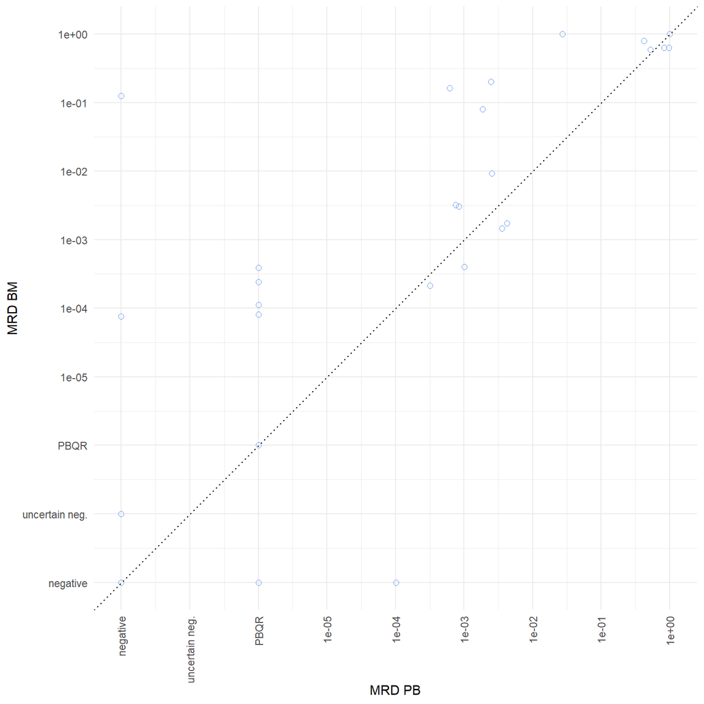

| BM_MRD | PB_MRD | count | pct |
| --- | --- | --- | --- |
| negative | negative | 67 | 69.1 |
| positive | positive | 17 | 17.5 |
| PBQR | PBQR | 4 | 4.1 |
| positive | PBQR | 4 | 4.1 |
| positive | negative | 2 | 2.1 |
| uncertain negative | negative | 1 | 1 |
| negative | PBQR | 1 | 1 |
| negative | positive | 1 | 1 |
| PBQR | negative | 0 | 0 |
| uncertain negative | PBQR | 0 | 0 |

[output cut: 2 more lines]

toDO-4: Distinguish B-myeloid and T-myeloid.

### 2.2.4 Burkitt

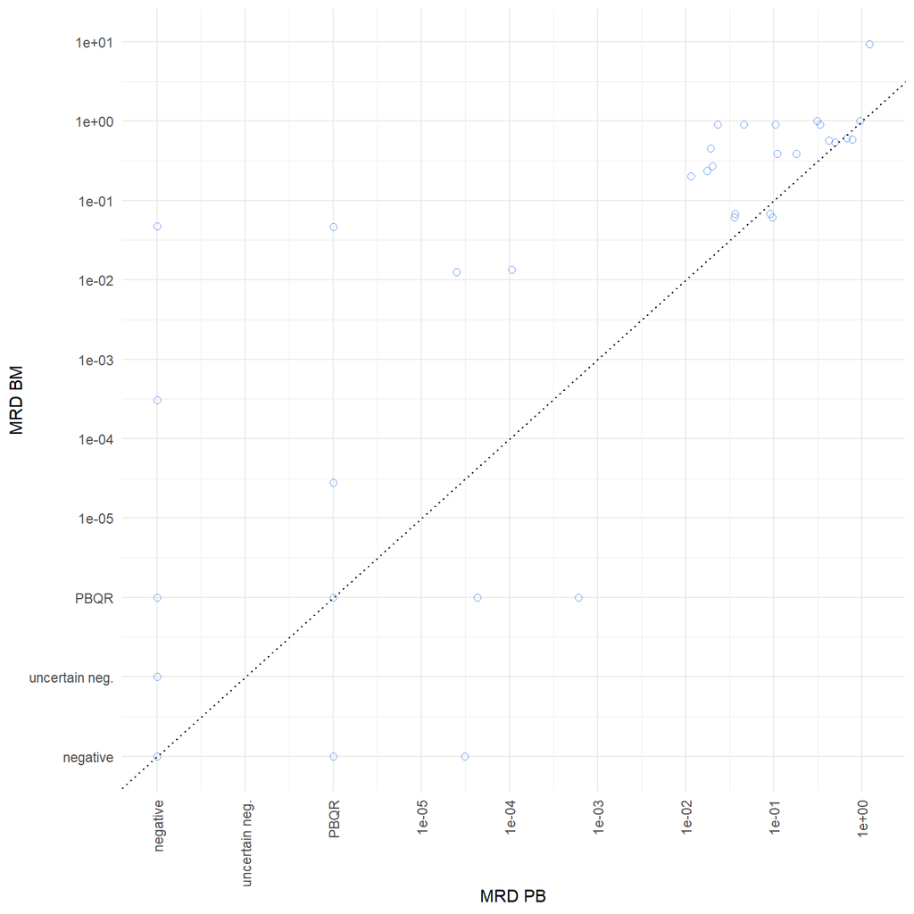

| BM_MRD | PB_MRD | count | pct |
| --- | --- | --- | --- |
| negative | negative | 62 | 62.6 |
| positive | positive | 23 | 23.2 |
| PBQR | negative | 3 | 3 |
| positive | negative | 2 | 2 |
| negative | PBQR | 2 | 2 |
| positive | PBQR | 2 | 2 |
| PBQR | positive | 2 | 2 |
| uncertain negative | negative | 1 | 1 |
| PBQR | PBQR | 1 | 1 |
| negative | positive | 1 | 1 |

[output cut: 2 more lines]

## 2.3 BM vs. BM-Trephine MRD

> BM and BM-Trephine samples collected <= 7 days apart.

### 2.3.1 B-ALL

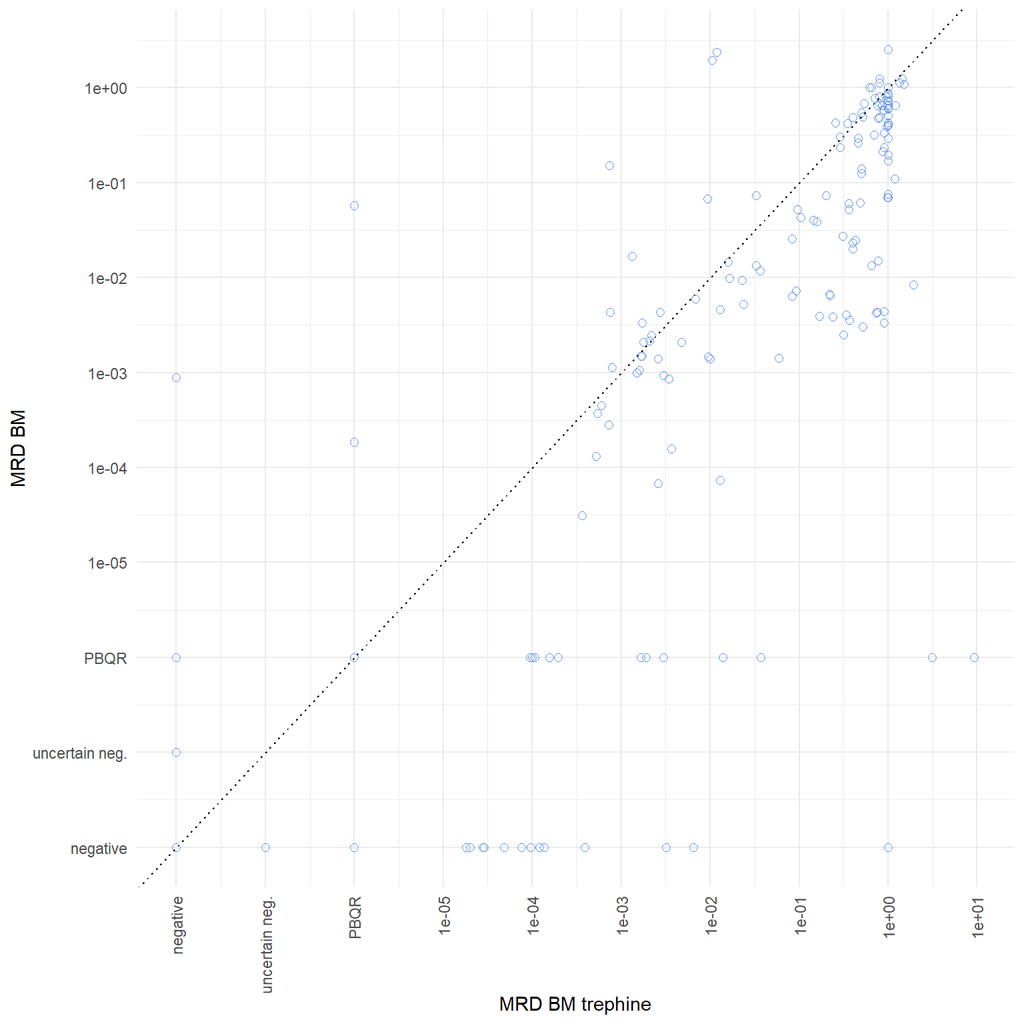

| BM_MRD | BMtreph_MRD | count | pct |
| --- | --- | --- | --- |
| negative | negative | 169 | 43.4 |
| positive | positive | 143 | 36.8 |
| negative | PBQR | 29 | 7.5 |
| negative | positive | 13 | 3.3 |
| PBQR | positive | 13 | 3.3 |
| PBQR | PBQR | 11 | 2.8 |
| PBQR | negative | 5 | 1.3 |
| uncertain negative | negative | 2 | 0.5 |
| positive | PBQR | 2 | 0.5 |
| positive | negative | 1 | 0.3 |

[output cut: 6 more lines]

### 2.3.2 T-ALL

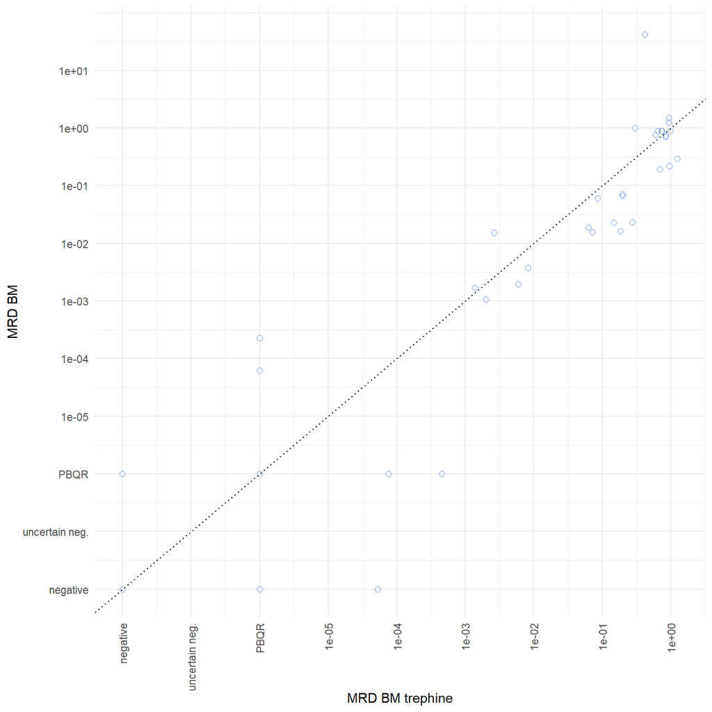

| BM_MRD | BMtreph_MRD | count | pct |
| --- | --- | --- | --- |
| positive | positive | 28 | 45.2 |
| negative | negative | 24 | 38.7 |
| negative | PBQR | 2 | 3.2 |
| PBQR | PBQR | 2 | 3.2 |
| positive | PBQR | 2 | 3.2 |
| PBQR | positive | 2 | 3.2 |
| PBQR | negative | 1 | 1.6 |
| negative | positive | 1 | 1.6 |
| positive | negative | 0 | 0 |

## 2.4 BM vs. BM-Trephine vs. PB MRD

> BM, BM-Trephine and PB triplets collected <= 7 days apart.

### 2.4.1 B-ALL

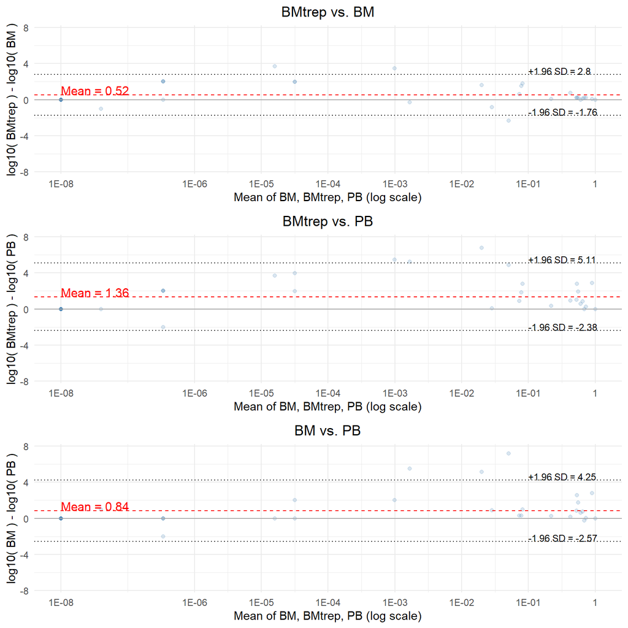

| MRD_BM_cat | MRD_PB_cat | MRD_BMtrep_cat | count | percent |
| --- | --- | --- | --- | --- |
| negative | negative | negative | 12 | 30.8 |
| negative | negative | PBQR | 3 | 7.7 |
| negative | negative | positive | 1 | 2.6 |
| negative | PBQR | negative | 1 | 2.6 |
| PBQR | negative | positive | 2 | 5.1 |
| PBQR | PBQR | positive | 1 | 2.6 |
| positive | negative | positive | 3 | 7.7 |
| positive | positive | positive | 15 | 38.5 |
| uncertain negative | negative | negative | 1 | 2.6 |

### 2.4.2 T-ALL

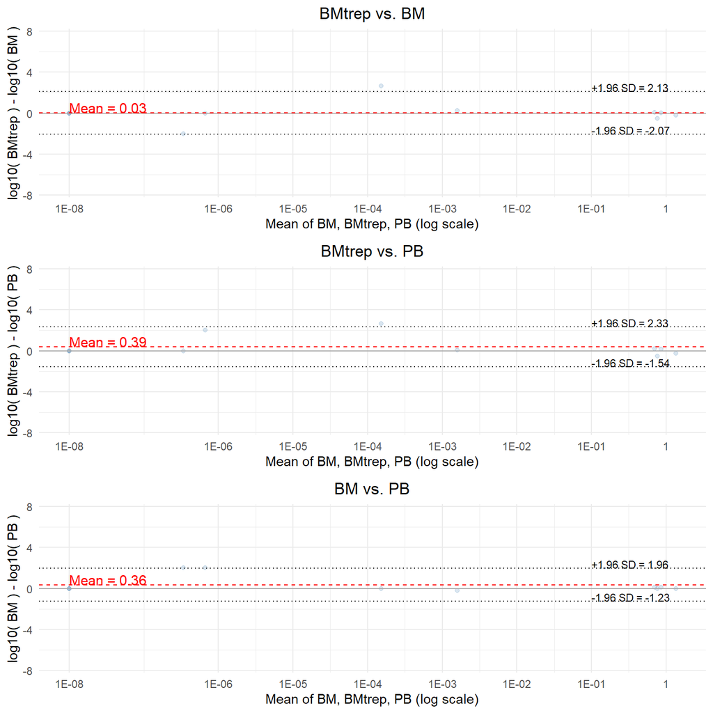

| MRD_BM_cat | MRD_PB_cat | MRD_BMtrep_cat | count | percent |
| --- | --- | --- | --- | --- |
| negative | negative | negative | 3 | 27.3 |
| PBQR | negative | negative | 1 | 9.1 |
| PBQR | negative | PBQR | 1 | 9.1 |
| PBQR | PBQR | positive | 1 | 9.1 |
| positive | positive | positive | 5 | 45.5 |

## 2.5 Sample CT values vs. MRD

### 2.5.1 All rearrangement classes

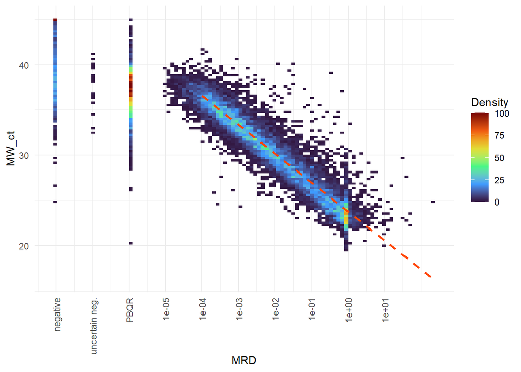

Density values capped at 100 for better resolution.

Trend curve calculated only for for samples with MRD >=1e-04.

toDO-5: Sample CTs <15 or >50 and those with no numeric values skipped for now.  
Please correct these values in the *RQ_gesamt_20250311.xlsx*.  
(columns: *ct_1*, *ct_2*, *ct_3*, *MW_ct* )

### 2.5.2 By rearrangement class

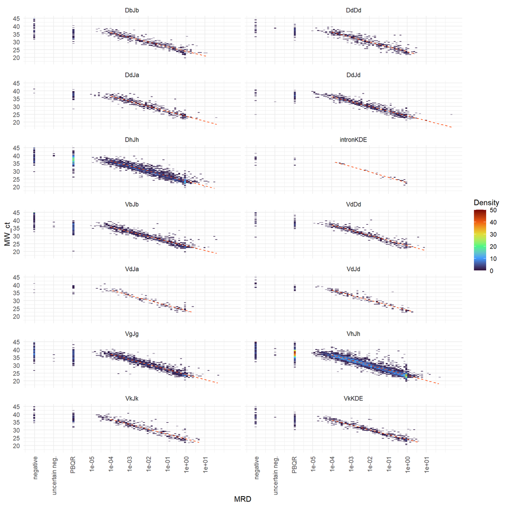

Density values capped at 50 for better resolution.

## 2.6 MRD by different target

> Same *dna-nr*, different *target*.

### 2.6.1 IG vs TR

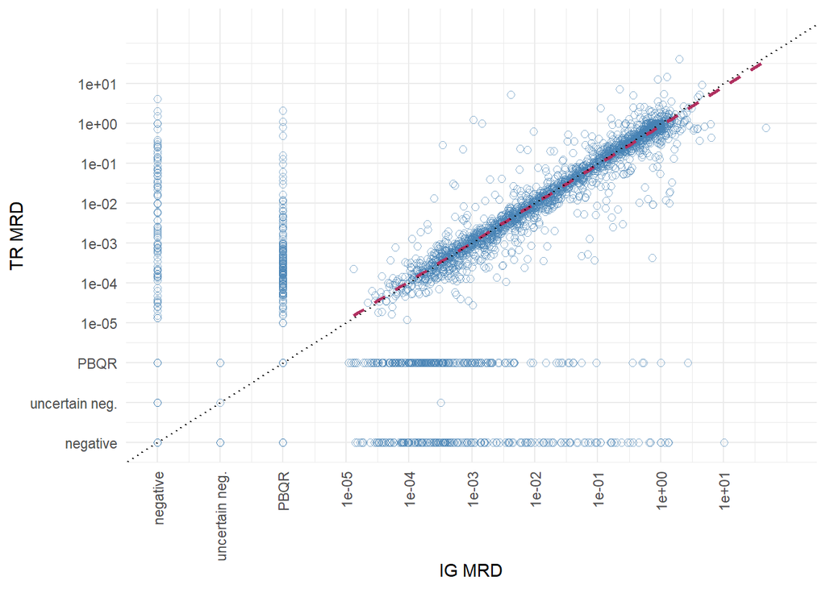

Trend curve calculated only for samples with both MRD values positive quantifiable.

### 2.6.2 IGH vs IGK

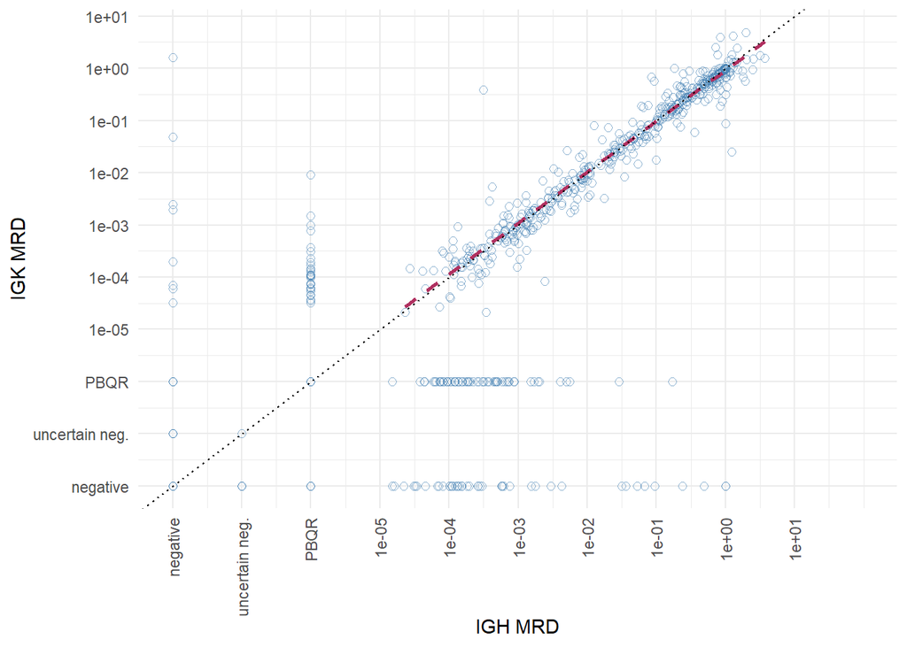

Trend curve calculated only for samples with both MRD values positive quantifiable.